# ISPE Code Sharing

2023-08-23

## 2. Literature review: summary and results

## Study objectives

Our primary objective was to quantify the number and proportion of papers in a key pharmacoepidemiology journal (Pharmacoepidemiology and Drug Safety [PDS]) which published all or part of their programming code over the period 2017 - 2022.

Secondary objectives:

- To describe the prevalence of code sharing according to key paper characteristics (article type, funding source, and whether the research topic covered COVID-19)
- Among papers who shared all or part of their code, to describe the method/platform used to share the code
- To describe the prevalence of other open research practices (study pre-registration, protocol sharing, data sharing, code-list sharing, use of checklists in the reporting, preprinting)

## Screening process

- We downloaded 1136 articles published in PDS between 2017 and 2022

  **Inclusion Criteria**
  1. Describes an analysis of real or simulated data

  **Exclusion Criteria**
  1. Lacks a full-text version (abstract only)
  2. Letters to the Editor or Commentaries

## A note on the inclusion criteria

- All papers which introduced new method included either a simulation study or a case study
- A small number of papers described methods more generally:
  - *Machine learning for improving high-dimensional proxy confounder adjustment in healthcare database studies: An overview of the current literature*
  - *Control yourself: ispe-endorsed guidance in the application of self-controlled study designs in pharmacoepidemiology*
- These papers did not generate any code, although in theory they could have added illustrative code
- We considered that papers for which no code was generated or could have been generated without changing the scope of the article were not eligible

## Flowchart of screening progress

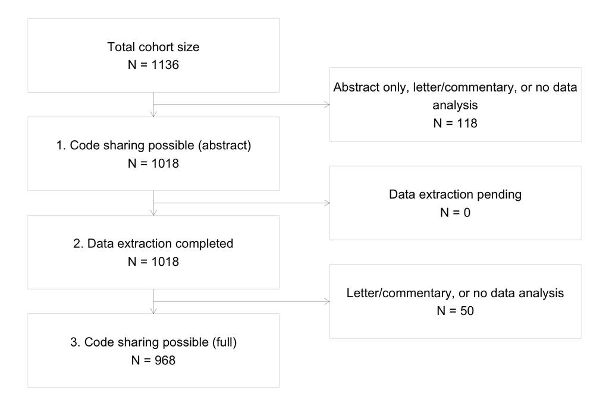

## Article characteristics

|  | Overall |
| --- | --- |
| n | 968 |
| Year (%) |  |
| 2017 | 168 (17.4) |
| 2018 | 163 (16.8) |
| 2019 | 180 (18.6) |
| 2020 | 166 (17.1) |
| 2021 | 164 (16.9) |
| 2022 | 127 (13.1) |
| Publication type (PDS) (%) |  |
| Brief Report | 62 ( 6.4) |
| Original Article | 879 (90.8) |
| Review | 27 ( 2.8) |
| Article type (%) |  |
| Applied | 617 (63.7) |
| Methodological | 142 (14.7) |
| Other | 3 ( 0.3) |
| Review | 63 ( 6.5) |
| Validation | 143 (14.8) |
| Simulation study = Yes (%) | 37 ( 3.8) |
| COVID-19 research = Yes (%) | 17 ( 1.8) |
| Industry affiliation reported = Yes (%) | 197 (20.4) |
| Industry funding reported = Yes (%) | 140 (14.5) |
| Reported programming language = Yes (%) | 688 (71.1) |
| SAS = Yes (%) | 320 (33.1) |
| R = Yes (%) | 169 (17.5) |
| Stata = Yes (%) | 164 (16.9) |
| SPSS/Excel = Yes (%) | 101 (10.4) |

## Geographical spread

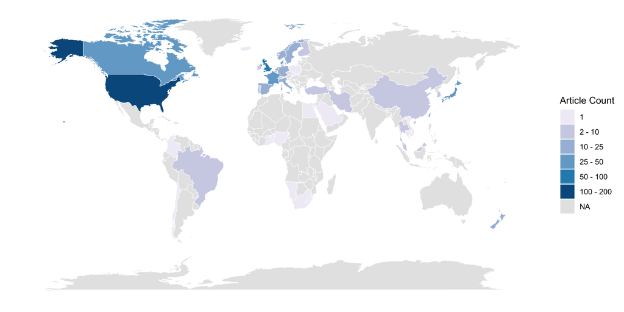

## Code sharing

- Overall, 62 papers mentioned or referenced code sharing in text or supplementary
- Of those, 48 (77.42%) had code which could be accessed without contacting the authors

\(~\)

\(~\)

**Of 968 articles, 48 (4.96%) shared code**

## Code sharing over time

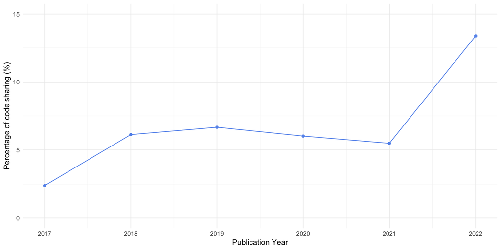

## Where was code shared?

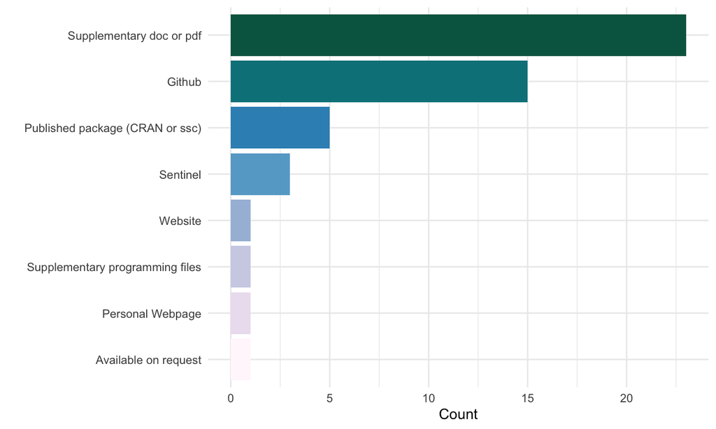

## Features of code sharing

|  | Overall |
| --- | --- |
| n | 48 |
| Shared code = TRUE (%) | 48 (100.0) |
| Were there instructions for how to run the code? (%) |  |
| No | 9 ( 18.8) |
| Yes in comments | 17 ( 35.4) |
| Yes, there is a README with instructions | 13 ( 27.1) |
| Yes, this is a published package with documentation | 9 ( 18.8) |
| Was synthetic data provided? = Yes (%) | 9 ( 18.8) |
| Was there a license? = Yes (%) | 11 ( 22.9) |
| R = Yes (%) | 23 ( 47.9) |
| SAS = Yes (%) | 13 ( 27.1) |
| Stata = Yes (%) | 11 ( 22.9) |
| Pipeline coverage: statistical analysis = Yes (%) | 26 ( 54.2) |
| Pipeline coverage: methods = Yes (%) | 10 ( 20.8) |
| Pipeline coverage: illustrative = Yes (%) | 13 ( 27.1) |
| Pipeline coverage: data management = Yes (%) | 20 ( 41.7) |

## Where a license was given, what was the license?

| license_type |
| --- |
| MIT |
| GPL v3.0 (https://www.gnu.org/licenses/gpl-3.0.txt) |
| The FDA hereby grants to all Collaborators a license to use the FDA Data and Materials for all purposes required in their respective roles for the duration of their participation in Mini-Sentinel and/… |
| Apache License 2.0 |
| CC0 1.0 Universal (CC0 1.0) |
| the 3-Clause BSD License (Open Source Initiative) |
| GLP v3 |

## Code sharing by other characteristics

|  | No | Yes |
| --- | --- | --- |
| n | 920 (95%) | 48 (5%) |
| Article type (%) |  |  |
| Applied | 605 (98%) | 12 (2%) |
| Methodological | 113 (80%) | 29 (20%) |
| Other | 2 (67%) | 1 (33%) |
| Review | 62 (98%) | 1 (2%) |
| Validation | 138 (97%) | 5 (3%) |
| Simulation study = Yes (%) | 22 (59%) | 15 (41%) |
| COVID-19 research = Yes (%) | 15 (88%) | 2 (12%) |
| Industry funding reported = Yes (%) | 135 (96%) | 5 (4%) |
| R = Yes (%) | 146 (86%) | 23 (14%) |
| Stata = Yes (%) | 153 (93%) | 11 (7%) |
| SAS = Yes (%) | 307 (96%) | 13 (4%) |

## Other open research practices

|  | Overall |
| --- | --- |
| n | 968 |
| Data sharing (%) |  |
| Data access procedures described or available on request | 75 ( 7.7) |
| No | 872 (90.1) |
| Yes | 21 ( 2.2) |
| Codelist sharing (%) |  |
| At least one | 499 (51.5) |
| No | 168 (17.4) |
| Not applicable | 291 (30.1) |
| Published Elsewhere | 10 ( 1.0) |
| Reporting guideline stated = Yes (%) | 44 ( 4.5) |
| Reported pre-registration = Yes (%) | 54 ( 5.6) |

## Which reporting guidelines were featured?

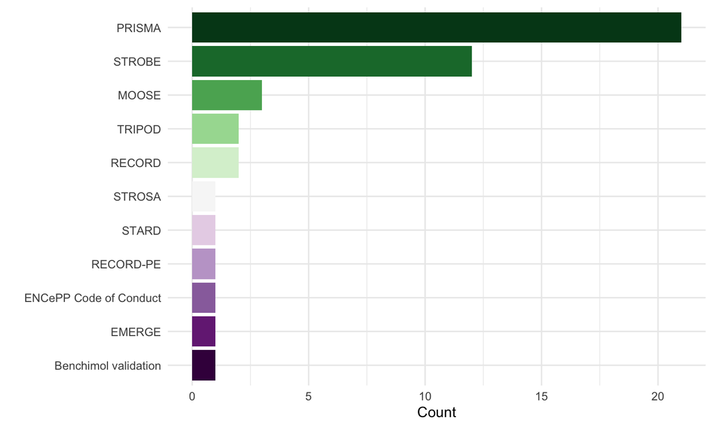

## 3. Literature review: discussion and feedback

## Tentative Conclusions

- Reporting on open research practices was not standardised
  - Some papers had an “Open Research” header, but the vast majority did not

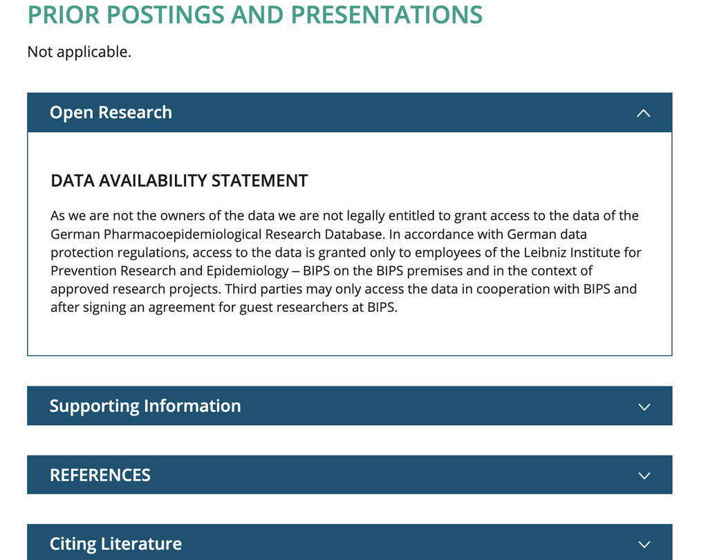

## Tentative Conclusions

- Reporting on open research practices was not standardised
  - Some papers had an “Open Research” header, but the vast majority did not
- Standardised reporting, for example as part of the submission portal process, could:
  - make information on open research practices more accessible and easier to find,
  - enable automated extraction tools to monitor progress
  - potentially increase the quality of open research reporting